# nf-gwas-pipeline

A Nextflow Genome-Wide Association Study (GWAS) Pipeline

### Clone Repository

```bash
$ git clone https://github.com/montilab/nf-gwas-pipeline
```

### Initalize Paths to Test Data

We have provided multiple toy datasets for testing the pipeline and ensuring all paths and dependencies are properly setup. To set the toy data paths to your local directory, run the following script.

```bash
$ cd nf-gwas-pipeline
$ python utils/paths.py
```

### Download Nextflow Executable

```bash
$ curl -s https://get.nextflow.io | bash
```

### Quick Start with Docker

We have created a pre-built Docker image with all of the dependencies installed. To get started, first make sure [Docker is installed](https://docs.docker.com/get-docker/). Then pull down the image onto your local machine.

```bash
$ docker pull montilab/gwas:latest
```

Optionally you could build this image yourself from the Dockerfile which specifies all of the dependencies required. *Note: This might take a while!*

```bash
$ docker build --tag montilab/gwas:latest .
```

### Run with docker

```bash
$ ./nextflow gwas.nf -c gwas.config -with-docker montilab/gwas
```

### Locally Run Example Data [Centos7]

You need to install the correponding versions of tools and ensure they are available.

```bash
$ module load R/3.6.0
$ module load vcftools/0.1.16
$ module load bcftools/1.10.2
$ module load annovar/2018apr
$ module load pandoc/2.5

# Modify paths and parameters in gwas.config file

$ nextflow gwas.nf -c gwas.config
```

### Expected Output

```bash
N E X T F L O W  ~  version 19.04.1
Launching `gwas.nf` [jolly_fermi] - revision: 46311ebd05
-

G W A S  ~  P I P E L I N E

================================
indir     : <YOUR PATH>/data/
outdir    : <YOUR PATH>/results

vcf       : <YOUR PATH>/data/toy_vcf.csv
pheno     : <YOUR PATH>/data/pheno_file_logistic.csv
snpset    : <YOUR PATH>/data/snpset.txt

phenotype : outcome
covars    : age,sex,PC1,PC2,PC3,PC4
model     : logistic
test      : Score
ref       : hg19

-
[warm up] executor > local
executor >  local (141)
[60/b5b95e] process > qc_miss                   [100%] 22 of 22 <e2><9c><94>
[11/fa0fbd] process > annovar_ref               [100%] 1 of 1 <e2><9c><94>
[8f/25f8fa] process > qc_mono                   [100%] 22 of 22 <e2><9c><94>
[82/069a6d] process > vcf_to_gds                [100%] 22 of 22 <e2><9c><94>
[3e/819e86] process > merge_gds                 [100%] 1 of 1 <e2><9c><94>
[c3/f23390] process > nullmod_skip_pca_grm      [100%] 1 of 1 <e2><9c><94>
[ed/91344b] process > gwas_skip_pca_grm         [100%] 22 of 22 <e2><9c><94>
[b4/3aea3e] process > caf_by_group_skip_pca_grm [100%] 22 of 22 <e2><9c><94>
[e2/3c778d] process > merge_by_chr              [100%] 22 of 22 <e2><9c><94>
[fe/33ebd4] process > combine_results           [100%] 1 of 1 <e2><9c><94>
[8b/2020d3] process > annovar_input             [100%] 1 of 1 <e2><9c><94>
[61/3a373f] process > plot                      [100%] 1 of 1 <e2><9c><94>
[66/6f4246] process > annovar                   [100%] 1 of 1 <e2><9c><94>
[85/d4266b] process > add_annovar               [100%] 1 of 1 <e2><9c><94>
[9e/4fc2fe] process > report                    [100%] 1 of 1 <e2><9c><94>
Completed at: 15-Oct-2020 17:30:28
Duration    : 44.1s
CPU hours   : 0.1
Succeeded   : 141
```

### Underlying Structure and Output folder

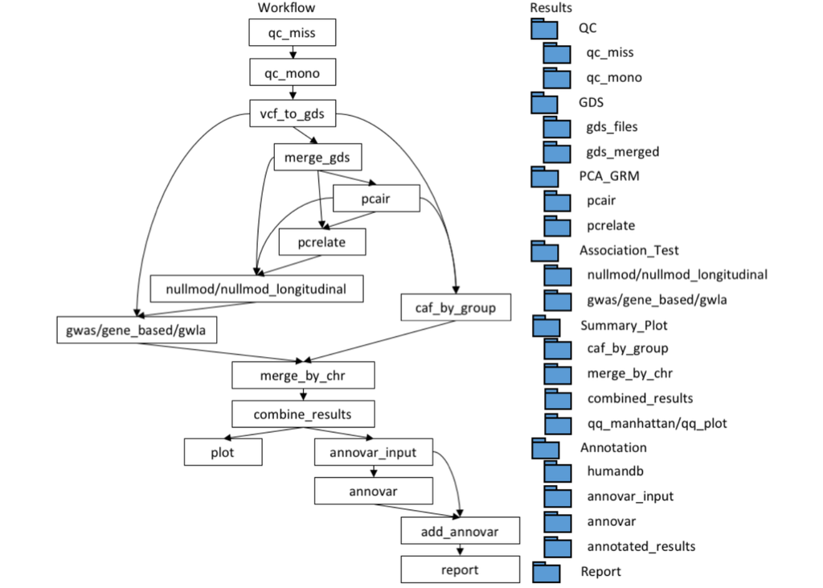

```r
display(readImage("./images/GWASpipeline_figure.png"))
```

### Mandatory Input file formats

####1.phenotype file: csv file

```bash
1. the first column should be the unique ID for subjects
2. names of the columns and numbers of columns are not fixed
3. the group variable is optional but should be a categorical variable if called
4. longitudinal phenotype file shoud be in long-format
5. if the pca_grm process is turned-off,  PCs should present in the phenotype file to be called

example: ./data/pheno_file_linear.csv
         ./data/pheno_file_logistic.csv
         ./data/1KG_pheno_linear.csv
         ./data/1KG_pheno_logistic.csv
         ./data/1KG_pheno_longitudinal.csv
```

```r
pheno.dat <- read.csv("./data/pheno_file_linear.csv")
kable(head(pheno.dat))
```

| ID | outcome | age | sex | PC1 | PC2 | PC3 | PC4 | group |
| --- | --- | --- | --- | --- | --- | --- | --- | --- |
| 202578640192_R09C01_202578640192_R09C01 | -1.1259198 | 53.03908 | F | -0.0048 | 0.0211 | 0.0389 | -0.0168 | group2 |
| 202579010063_R05C02_202579010063_R05C02 | -2.3237168 | 59.39922 | F | -0.0383 | -0.0157 | 0.0061 | 0.0108 | group2 |
| 202578650131_R04C02_202578650131_R04C02 | 0.0589976 | 22.27178 | F | -0.0356 | -0.0149 | -0.0159 | 0.0113 | group3 |
| 202582730083_R09C01_202582730083_R09C01 | 0.9995060 | 68.75518 | M | 0.0079 | -0.0043 | -0.0103 | -0.0257 | group1 |
| 202578640258_R03C02_202578640258_R03C02 | -0.9547252 | 23.48552 | F | 0.0148 | -0.0079 | 0.0120 | 0.0058 | group3 |
| 202578650131_R05C01_202578650131_R05C01 | 0.5786668 | 11.09063 | M | 0.0065 | 0.0030 | -0.0128 | 0.0157 | group3 |

####2.genotype file: vcf.gz file

```bash
1. vcf.gz files at least contains the GT column
2. the ID column would end up being the snpID in the final output
3. vcf.file should contain DS column to use dosages in GWAS (imputed=T)

example: ./data/vcf/vcf_file1.vcf.gz
         ./data/1KG_vcf/1KG_phase3_subset_chr1.vcf.gz
```

####3.mapping file: csv file

```bash
1. two-column csv file mapping the prefix to the vcf.gz files
2. the results for each chromosome will be names be the corresponding prefix
3. NO header

example: ./data/toy_vcf.csv
         ./data/1KG_vcf.csv
```

```r
map.dat <- read.csv("./data/toy_vcf.csv")
kable(head(map.dat))
```

| chr_1 | X.rprojectnb2.necs.Zeyuan_Analysis.GWASpipeline.GWAS_pipeline_up_to_date.nf.gwas.pipeline.data.vcf.vcf_file1.vcf.gz |
| --- | --- |
| chr_2 | /rprojectnb2/necs/Zeyuan_Analysis/GWASpipeline/GWAS_pipeline_up_to_date/nf-gwas-pipeline/data/vcf/vcf_file2.vcf.gz |
| chr_3 | /rprojectnb2/necs/Zeyuan_Analysis/GWASpipeline/GWAS_pipeline_up_to_date/nf-gwas-pipeline/data/vcf/vcf_file3.vcf.gz |
| chr_4 | /rprojectnb2/necs/Zeyuan_Analysis/GWASpipeline/GWAS_pipeline_up_to_date/nf-gwas-pipeline/data/vcf/vcf_file4.vcf.gz |
| chr_5 | /rprojectnb2/necs/Zeyuan_Analysis/GWASpipeline/GWAS_pipeline_up_to_date/nf-gwas-pipeline/data/vcf/vcf_file5.vcf.gz |
| chr_6 | /rprojectnb2/necs/Zeyuan_Analysis/GWASpipeline/GWAS_pipeline_up_to_date/nf-gwas-pipeline/data/vcf/vcf_file6.vcf.gz |
| chr_7 | /rprojectnb2/necs/Zeyuan_Analysis/GWASpipeline/GWAS_pipeline_up_to_date/nf-gwas-pipeline/data/vcf/vcf_file7.vcf.gz |

### Optional Input file formats

####1.SNP set

```bash
1. two column txt file seperated by ","
2. first column shoud be chromosome and second column be physical position with fixed header "chr,pos"

example: ./data/snpset.txt
```

```r
snp.dat <- fread("./data/snpset.txt")
kable(head(snp.dat))
```

| chr | pos |
| --- | --- |
| 1 | 1165522 |
| 1 | 1176433 |
| 1 | 1179532 |
| 1 | 1188944 |
| 1 | 1781220 |
| 2 | 1018108 |

####2.Genetic relationship matrix

```bash
1. a symmetric matrix saved in rds format with both columns being subjects
2. can be replaced by 2*kinship matrix
```

```r
grm <- readRDS("./data/grm.rds")
kable(grm[1:5,1:5])
```

|  | HG00110 | HG00116 | HG00120 | HG00128 | HG00136 |
| --- | --- | --- | --- | --- | --- |
| HG00110 | 1.0332116 | -0.0179534 | 0.0070812 | -0.0114037 | -0.0122968 |
| HG00116 | -0.0179534 | 0.9901158 | 0.1161200 | -0.0369330 | -0.0204240 |
| HG00120 | 0.0070812 | 0.1161200 | 0.9772376 | -0.0595185 | -0.0337373 |
| HG00128 | -0.0114037 | -0.0369330 | -0.0595185 | 0.9500809 | -0.0373967 |
| HG00136 | -0.0122968 | -0.0204240 | -0.0337373 | -0.0373967 | 0.9740444 |

### GWAS example

####Input file: #####1.phenotype csv

```r
pheno.dat <- read.csv("./data/1KG_pheno_logistic.csv")
kable(head(pheno.dat))
```

| sample.id | Population | sex | outcome |
| --- | --- | --- | --- |
| HG00110 | GBR | F | 1 |
| HG00116 | GBR | M | 1 |
| HG00120 | GBR | F | 0 |
| HG00128 | GBR | F | 1 |
| HG00136 | GBR | M | 0 |
| HG00137 | GBR | F | 0 |

#####2.mapping file

```r
map.dat <- read.csv("./data/1KG_vcf.csv")
kable(head(map.dat))
```

| chr_1 | X.rprojectnb2.necs.Zeyuan_Analysis.GWASpipeline.GWAS_pipeline_up_to_date.nf.gwas.pipeline.data.1KG_vcf.1KG_phase3_subset_chr1.vcf.gz |
| --- | --- |
| chr_2 | /rprojectnb2/necs/Zeyuan_Analysis/GWASpipeline/GWAS_pipeline_up_to_date/nf-gwas-pipeline/data/1KG_vcf/1KG_phase3_subset_chr2.vcf.gz |
| chr_3 | /rprojectnb2/necs/Zeyuan_Analysis/GWASpipeline/GWAS_pipeline_up_to_date/nf-gwas-pipeline/data/1KG_vcf/1KG_phase3_subset_chr3.vcf.gz |
| chr_4 | /rprojectnb2/necs/Zeyuan_Analysis/GWASpipeline/GWAS_pipeline_up_to_date/nf-gwas-pipeline/data/1KG_vcf/1KG_phase3_subset_chr4.vcf.gz |
| chr_5 | /rprojectnb2/necs/Zeyuan_Analysis/GWASpipeline/GWAS_pipeline_up_to_date/nf-gwas-pipeline/data/1KG_vcf/1KG_phase3_subset_chr5.vcf.gz |
| chr_6 | /rprojectnb2/necs/Zeyuan_Analysis/GWASpipeline/GWAS_pipeline_up_to_date/nf-gwas-pipeline/data/1KG_vcf/1KG_phase3_subset_chr6.vcf.gz |
| chr_7 | /rprojectnb2/necs/Zeyuan_Analysis/GWASpipeline/GWAS_pipeline_up_to_date/nf-gwas-pipeline/data/1KG_vcf/1KG_phase3_subset_chr7.vcf.gz |

#####3.genotype file see mapping file

####Execution:

```bash
run with .config file:
nextflow run gwas.nf -c $PWD/configs/gwas_1KG_logistic.config

run with equivalent command:
nextflow run gwas.nf --vcf_list $PWD/data/1KG_vcf.csv --pheno $PWD/data/1KG_pheno_logistic.csv --phenotype outcome --covars sex,PC1,PC2,PC3,PC4 --pca_grm --model logistic --test Score --gwas --group Population --min_maf 0.1 --max_pval_manhattan 0.5 --max_pval 0.05 --ref_genome hg19
```

### Gene-based example

####Input file: #####1.phenotype csv

```r
pheno.dat <- read.csv("./data/1KG_pheno_linear.csv")
kable(head(pheno.dat))
```

| sample.id | Population | sex | outcome |
| --- | --- | --- | --- |
| HG00110 | GBR | F | 1.2114051 |
| HG00116 | GBR | M | 1.4196076 |
| HG00120 | GBR | F | 0.0119097 |
| HG00128 | GBR | F | 0.6800792 |
| HG00136 | GBR | M | -2.3179815 |
| HG00137 | GBR | F | -1.4958842 |

#####2.mapping file

```r
map.dat <- read.csv("./data/1KG_vcf.csv")
kable(head(map.dat))
```

| chr_1 | X.rprojectnb2.necs.Zeyuan_Analysis.GWASpipeline.GWAS_pipeline_up_to_date.nf.gwas.pipeline.data.1KG_vcf.1KG_phase3_subset_chr1.vcf.gz |
| --- | --- |
| chr_2 | /rprojectnb2/necs/Zeyuan_Analysis/GWASpipeline/GWAS_pipeline_up_to_date/nf-gwas-pipeline/data/1KG_vcf/1KG_phase3_subset_chr2.vcf.gz |
| chr_3 | /rprojectnb2/necs/Zeyuan_Analysis/GWASpipeline/GWAS_pipeline_up_to_date/nf-gwas-pipeline/data/1KG_vcf/1KG_phase3_subset_chr3.vcf.gz |
| chr_4 | /rprojectnb2/necs/Zeyuan_Analysis/GWASpipeline/GWAS_pipeline_up_to_date/nf-gwas-pipeline/data/1KG_vcf/1KG_phase3_subset_chr4.vcf.gz |
| chr_5 | /rprojectnb2/necs/Zeyuan_Analysis/GWASpipeline/GWAS_pipeline_up_to_date/nf-gwas-pipeline/data/1KG_vcf/1KG_phase3_subset_chr5.vcf.gz |
| chr_6 | /rprojectnb2/necs/Zeyuan_Analysis/GWASpipeline/GWAS_pipeline_up_to_date/nf-gwas-pipeline/data/1KG_vcf/1KG_phase3_subset_chr6.vcf.gz |
| chr_7 | /rprojectnb2/necs/Zeyuan_Analysis/GWASpipeline/GWAS_pipeline_up_to_date/nf-gwas-pipeline/data/1KG_vcf/1KG_phase3_subset_chr7.vcf.gz |

#####3.genotype file see mapping file

####Execution:

```bash
run with .config file:
nextflow run gwas.nf -c $PWD/configs/gene_1KG_linear.config

run with equivalent command:
nextflow run gwas.nf --vcf_list $PWD/data/1KG_vcf.csv --pheno $PWD/data/1KG_pheno_linear.csv --phenotype outcome --covars PC1,PC2,PC3,PC4 --pca_grm --model linear --test Score --gene_based --group Population --max_pval 0.01 --ref_genome hg19
```

### GWLA example

####Input file: #####1.phenotype csv

```r
pheno.dat <- read.csv("./data/1KG_pheno_longitudinal.csv")
kable(head(pheno.dat))
```

| sample.id | Population | sex | age | delta.age | outcome |
| --- | --- | --- | --- | --- | --- |
| HG00110 | GBR | F | 46 | 0 | 1.2114051 |
| HG00110 | GBR | F | 53 | 7 | 3.1471562 |
| HG00116 | GBR | M | 51 | 0 | 1.4196076 |
| HG00116 | GBR | M | 57 | 6 | 1.9318303 |
| HG00120 | GBR | F | 49 | 0 | 0.0119097 |
| HG00120 | GBR | F | 57 | 8 | 3.1782473 |

#####2.mapping file

```r
map.dat <- read.csv("./data/1KG_vcf.csv")
kable(head(map.dat))
```

| chr_1 | X.rprojectnb2.necs.Zeyuan_Analysis.GWASpipeline.GWAS_pipeline_up_to_date.nf.gwas.pipeline.data.1KG_vcf.1KG_phase3_subset_chr1.vcf.gz |
| --- | --- |
| chr_2 | /rprojectnb2/necs/Zeyuan_Analysis/GWASpipeline/GWAS_pipeline_up_to_date/nf-gwas-pipeline/data/1KG_vcf/1KG_phase3_subset_chr2.vcf.gz |
| chr_3 | /rprojectnb2/necs/Zeyuan_Analysis/GWASpipeline/GWAS_pipeline_up_to_date/nf-gwas-pipeline/data/1KG_vcf/1KG_phase3_subset_chr3.vcf.gz |
| chr_4 | /rprojectnb2/necs/Zeyuan_Analysis/GWASpipeline/GWAS_pipeline_up_to_date/nf-gwas-pipeline/data/1KG_vcf/1KG_phase3_subset_chr4.vcf.gz |
| chr_5 | /rprojectnb2/necs/Zeyuan_Analysis/GWASpipeline/GWAS_pipeline_up_to_date/nf-gwas-pipeline/data/1KG_vcf/1KG_phase3_subset_chr5.vcf.gz |
| chr_6 | /rprojectnb2/necs/Zeyuan_Analysis/GWASpipeline/GWAS_pipeline_up_to_date/nf-gwas-pipeline/data/1KG_vcf/1KG_phase3_subset_chr6.vcf.gz |
| chr_7 | /rprojectnb2/necs/Zeyuan_Analysis/GWASpipeline/GWAS_pipeline_up_to_date/nf-gwas-pipeline/data/1KG_vcf/1KG_phase3_subset_chr7.vcf.gz |

#####3.genotype file see mapping file

####Execution:

```bash
run with .config file:
nextflow run gwas.nf -c $PWD/configs/gwla_1KG_linear_slope.config

run with equivalent command:
nextflow run gwas.nf --vcf_list $PWD/data/1KG_vcf.csv --pheno $PWD/data/1KG_pheno_longitudinal.csv --phenotype outcome --covars sex,age,PC1,PC2,PC3,PC4 --pca_grm --model linear --test Score --longitudinal --group Population --min_maf 0.1 --max_pval_manhattan 0.5 --max_pval 0.01 --ref_genome hg19
```